# ASSIGNMENT 2

## ——————————————————————————–

## *Mungunchimeg Batbayar* **s4662982**

## ——————————————————————————–

### **1.Display the first 10 rows of the dataset using `kable()` function**

Install the packages and load the data set.

```r
library(tidyverse)
library(skimr)
library(tidymodels)
library(modeldata)
library(knitr)


thanksgiving_meals <- read_csv("https://raw.githubusercontent.com/rfordatascience/tidytuesday/master/data/2018/2018-11-20/thanksgiving_meals.csv")
kable(thanksgiving_meals[1:10, ], "simple")
```

| id | celebrate | main_dish | main_dish_other | main_prep | main_prep_other | stuffing | stuffing_other | cranberry | cranberry_other | gravy | side1 | side2 | side3 | side4 | side5 | side6 | side7 | side8 | side9 | side10 | side11 | side12 | side13 | side14 | side15 | pie1 | pie2 | pie3 | pie4 | … |
| --- | --- | --- | --- | --- | --- | --- | --- | --- | --- | --- | --- | --- | --- | --- | --- | --- | --- | --- | --- | --- | --- | --- | --- | --- | --- | --- | --- | --- | --- | --- |
| 4337954960 | Yes | Turkey | NA | Baked | NA | Bread-based | NA | None | NA | Yes | NA | Carrots | NA | NA | NA | NA | Green beans/green bean casserole | Macaroni and cheese | Mashed potatoes | NA | NA | NA | Yams/sweet potato casserole | NA | NA | Apple | NA | NA | NA | … |
| 4337951949 | Yes | Turkey | NA | Baked | NA | Bread-based | NA | Other (please specify) | Homemade cranberry gelatin ring | Yes | NA | NA | NA | Corn | NA | NA | Green beans/green bean casserole | Macaroni and cheese | Mashed potatoes | Rolls/biscuits | NA | Vegetable salad | Yams/sweet potato casserole | Other (please specify) | Asian vinagrette salad | Apple | NA | NA | Chocolate | … |
| 4337935621 | Yes | Turkey | NA | Roasted | NA | Rice-based | NA | Homemade | NA | Yes | Brussel sprouts | Carrots | Cauliflower | Corn | Cornbread | NA | NA | NA | Mashed potatoes | Rolls/biscuits | NA | Vegetable salad | NA | NA | NA | Apple | NA | Cherry | NA | … |
| 4337933040 | Yes | Turkey | NA | Baked | NA | Bread-based | NA | Homemade | NA | Yes | Brussel sprouts | NA | NA | NA | Cornbread | NA | NA | NA | Mashed potatoes | Rolls/biscuits | NA | Vegetable salad | Yams/sweet potato casserole | NA | NA | NA | NA | NA | NA | … |
| 4337931983 | Yes | Tofurkey | NA | Baked | NA | Bread-based | NA | Canned | NA | Yes | Brussel sprouts | NA | NA | NA | Cornbread | NA | NA | NA | Mashed potatoes | Rolls/biscuits | Squash | Vegetable salad | Yams/sweet potato casserole | NA | NA | Apple | NA | NA | NA | … |
| 4337929779 | Yes | Turkey | NA | Roasted | NA | Rice-based | NA | Homemade | NA | Yes | Brussel sprouts | Carrots | Cauliflower | Corn | Cornbread | Fruit salad | Green beans/green bean casserole | Macaroni and cheese | Mashed potatoes | Rolls/biscuits | Squash | Vegetable salad | Yams/sweet potato casserole | NA | NA | NA | NA | NA | NA | … |
| 4337924420 | Yes | Turkey | NA | Baked | NA | Bread-based | NA | Canned | NA | Yes | NA | NA | NA | NA | NA | Fruit salad | Green beans/green bean casserole | NA | Mashed potatoes | Rolls/biscuits | NA | NA | Yams/sweet potato casserole | NA | NA | Apple | NA | NA | NA | … |
| 4337916002 | Yes | Turkey | NA | Baked | NA | Rice-based | NA | Homemade | NA | Yes | NA | Carrots | NA | NA | NA | NA | NA | NA | NA | NA | NA | NA | NA | NA | NA | NA | NA | NA | Chocolate | … |
| 4337914977 | Yes | Turkey | NA | Roasted | NA | Bread-based | NA | Canned | NA | Yes | Brussel sprouts | NA | NA | Corn | Cornbread | NA | Green beans/green bean casserole | NA | Mashed potatoes | Rolls/biscuits | Squash | NA | NA | NA | NA | Apple | Buttermilk | NA | NA | … |
| 4337899817 | Yes | Other (please specify) | Turkey and Ham | Baked | NA | Bread-based | NA | Other (please specify) | Both Canned and Homemade | Yes | Brussel sprouts | Carrots | NA | NA | NA | NA | Green beans/green bean casserole | NA | Mashed potatoes | Rolls/biscuits | NA | NA | Yams/sweet potato casserole | NA | NA | NA | Buttermilk | NA | NA | … |

### **2.Using `skim()` display the summary of variables. Think about the task to predict a family income based on their menu: what variables may be useful? Are all of them correct type? Write 2-3 sentences with your explanation.**

### **Think about the task to predict a community type or US_region based on their menu: what variables may be useful? Are all of them correct type?**

```r
skim(thanksgiving_meals)
```

Data summary

| Name | thanksgiving_meals |
| --- | --- |
| Number of rows | 1058 |
| Number of columns | 65 |
| _______________________ |  |
| Column type frequency: |  |
| character | 64 |
| numeric | 1 |
| ________________________ |  |
| Group variables | None |

**Variable type: character**

| skim_variable | n_missing | complete_rate | min | max | empty | n_unique | whitespace |
| --- | --- | --- | --- | --- | --- | --- | --- |
| celebrate | 0 | 1.00 | 2 | 3 | 0 | 2 | 0 |
| main_dish | 84 | 0.92 | 6 | 22 | 0 | 8 | 0 |
| main_dish_other | 1023 | 0.03 | 4 | 85 | 0 | 32 | 0 |
| main_prep | 84 | 0.92 | 5 | 22 | 0 | 5 | 0 |
| main_prep_other | 1007 | 0.05 | 1 | 33 | 0 | 32 | 0 |
| stuffing | 84 | 0.92 | 4 | 22 | 0 | 4 | 0 |
| stuffing_other | 1022 | 0.03 | 4 | 46 | 0 | 29 | 0 |
| cranberry | 84 | 0.92 | 4 | 22 | 0 | 4 | 0 |
| cranberry_other | 1033 | 0.02 | 3 | 61 | 0 | 24 | 0 |
| gravy | 84 | 0.92 | 2 | 3 | 0 | 2 | 0 |
| side1 | 903 | 0.15 | 15 | 15 | 0 | 1 | 0 |
| side2 | 816 | 0.23 | 7 | 7 | 0 | 1 | 0 |
| side3 | 970 | 0.08 | 11 | 11 | 0 | 1 | 0 |
| side4 | 594 | 0.44 | 4 | 4 | 0 | 1 | 0 |
| side5 | 823 | 0.22 | 9 | 9 | 0 | 1 | 0 |
| side6 | 843 | 0.20 | 11 | 11 | 0 | 1 | 0 |
| side7 | 372 | 0.65 | 32 | 32 | 0 | 1 | 0 |
| side8 | 852 | 0.19 | 19 | 19 | 0 | 1 | 0 |
| side9 | 241 | 0.77 | 15 | 15 | 0 | 1 | 0 |
| side10 | 292 | 0.72 | 14 | 14 | 0 | 1 | 0 |
| side11 | 887 | 0.16 | 6 | 6 | 0 | 1 | 0 |
| side12 | 849 | 0.20 | 15 | 15 | 0 | 1 | 0 |
| side13 | 427 | 0.60 | 27 | 27 | 0 | 1 | 0 |
| side14 | 947 | 0.10 | 22 | 22 | 0 | 1 | 0 |
| side15 | 947 | 0.10 | 4 | 78 | 0 | 89 | 0 |
| pie1 | 544 | 0.49 | 5 | 5 | 0 | 1 | 0 |
| pie2 | 1023 | 0.03 | 10 | 10 | 0 | 1 | 0 |
| pie3 | 945 | 0.11 | 6 | 6 | 0 | 1 | 0 |
| pie4 | 925 | 0.13 | 9 | 9 | 0 | 1 | 0 |
| pie5 | 1022 | 0.03 | 13 | 13 | 0 | 1 | 0 |
| pie6 | 1019 | 0.04 | 8 | 8 | 0 | 1 | 0 |
| pie7 | 1024 | 0.03 | 5 | 5 | 0 | 1 | 0 |
| pie8 | 716 | 0.32 | 5 | 5 | 0 | 1 | 0 |
| pie9 | 329 | 0.69 | 7 | 7 | 0 | 1 | 0 |
| pie10 | 906 | 0.14 | 12 | 12 | 0 | 1 | 0 |
| pie11 | 1018 | 0.04 | 4 | 4 | 0 | 1 | 0 |
| pie12 | 987 | 0.07 | 22 | 22 | 0 | 1 | 0 |
| pie13 | 987 | 0.07 | 5 | 46 | 0 | 61 | 0 |
| dessert1 | 948 | 0.10 | 13 | 13 | 0 | 1 | 0 |
| dessert2 | 1042 | 0.02 | 8 | 8 | 0 | 1 | 0 |
| dessert3 | 930 | 0.12 | 8 | 8 | 0 | 1 | 0 |
| dessert4 | 986 | 0.07 | 11 | 11 | 0 | 1 | 0 |
| dessert5 | 867 | 0.18 | 10 | 10 | 0 | 1 | 0 |
| dessert6 | 854 | 0.19 | 7 | 7 | 0 | 1 | 0 |
| dessert7 | 1015 | 0.04 | 5 | 5 | 0 | 1 | 0 |
| dessert8 | 792 | 0.25 | 9 | 9 | 0 | 1 | 0 |
| dessert9 | 955 | 0.10 | 13 | 13 | 0 | 1 | 0 |
| dessert10 | 763 | 0.28 | 4 | 4 | 0 | 1 | 0 |
| dessert11 | 924 | 0.13 | 22 | 22 | 0 | 1 | 0 |
| dessert12 | 924 | 0.13 | 3 | 59 | 0 | 92 | 0 |
| prayer | 99 | 0.91 | 2 | 3 | 0 | 2 | 0 |
| travel | 107 | 0.90 | 59 | 80 | 0 | 4 | 0 |
| watch_program | 556 | 0.47 | 13 | 13 | 0 | 1 | 0 |
| kids_table_age | 107 | 0.90 | 2 | 13 | 0 | 12 | 0 |
| hometown_friends | 107 | 0.90 | 2 | 3 | 0 | 2 | 0 |
| friendsgiving | 107 | 0.90 | 2 | 3 | 0 | 2 | 0 |
| black_friday | 107 | 0.90 | 2 | 3 | 0 | 2 | 0 |
| work_retail | 107 | 0.90 | 2 | 3 | 0 | 2 | 0 |
| work_black_friday | 988 | 0.07 | 2 | 13 | 0 | 3 | 0 |
| community_type | 110 | 0.90 | 5 | 8 | 0 | 3 | 0 |
| age | 33 | 0.97 | 3 | 7 | 0 | 4 | 0 |
| gender | 33 | 0.97 | 4 | 6 | 0 | 2 | 0 |
| family_income | 33 | 0.97 | 12 | 20 | 0 | 11 | 0 |
| us_region | 59 | 0.94 | 7 | 18 | 0 | 9 | 0 |

**Variable type: numeric**

| skim_variable | n_missing | complete_rate | mean | sd | p0 | p25 | p50 | p75 | p100 | hist |
| --- | --- | --- | --- | --- | --- | --- | --- | --- | --- | --- |
| id | 0 | 1 | 4336731188 | 493783.4 | 4335894916 | 4336339486 | 4336796628 | 4337012140 | 4337954960 | ▅▃▇▂▂ |

```r
kable(skim(thanksgiving_meals))
```

| skim_type | skim_variable | n_missing | complete_rate | character.min | character.max | character.empty | character.n_unique | character.whitespace | numeric.mean | numeric.sd | numeric.p0 | numeric.p25 | numeric.p50 | numeric.p75 | numeric.p100 | numeric.hist |
| --- | --- | --- | --- | --- | --- | --- | --- | --- | --- | --- | --- | --- | --- | --- | --- | --- |
| character | celebrate | 0 | 1.0000000 | 2 | 3 | 0 | 2 | 0 | NA | NA | NA | NA | NA | NA | NA | NA |
| character | main_dish | 84 | 0.9206049 | 6 | 22 | 0 | 8 | 0 | NA | NA | NA | NA | NA | NA | NA | NA |
| character | main_dish_other | 1023 | 0.0330813 | 4 | 85 | 0 | 32 | 0 | NA | NA | NA | NA | NA | NA | NA | NA |
| character | main_prep | 84 | 0.9206049 | 5 | 22 | 0 | 5 | 0 | NA | NA | NA | NA | NA | NA | NA | NA |
| character | main_prep_other | 1007 | 0.0482042 | 1 | 33 | 0 | 32 | 0 | NA | NA | NA | NA | NA | NA | NA | NA |
| character | stuffing | 84 | 0.9206049 | 4 | 22 | 0 | 4 | 0 | NA | NA | NA | NA | NA | NA | NA | NA |
| character | stuffing_other | 1022 | 0.0340265 | 4 | 46 | 0 | 29 | 0 | NA | NA | NA | NA | NA | NA | NA | NA |
| character | cranberry | 84 | 0.9206049 | 4 | 22 | 0 | 4 | 0 | NA | NA | NA | NA | NA | NA | NA | NA |
| character | cranberry_other | 1033 | 0.0236295 | 3 | 61 | 0 | 24 | 0 | NA | NA | NA | NA | NA | NA | NA | NA |
| character | gravy | 84 | 0.9206049 | 2 | 3 | 0 | 2 | 0 | NA | NA | NA | NA | NA | NA | NA | NA |
| character | side1 | 903 | 0.1465028 | 15 | 15 | 0 | 1 | 0 | NA | NA | NA | NA | NA | NA | NA | NA |
| character | side2 | 816 | 0.2287335 | 7 | 7 | 0 | 1 | 0 | NA | NA | NA | NA | NA | NA | NA | NA |
| character | side3 | 970 | 0.0831758 | 11 | 11 | 0 | 1 | 0 | NA | NA | NA | NA | NA | NA | NA | NA |
| character | side4 | 594 | 0.4385633 | 4 | 4 | 0 | 1 | 0 | NA | NA | NA | NA | NA | NA | NA | NA |
| character | side5 | 823 | 0.2221172 | 9 | 9 | 0 | 1 | 0 | NA | NA | NA | NA | NA | NA | NA | NA |
| character | side6 | 843 | 0.2032136 | 11 | 11 | 0 | 1 | 0 | NA | NA | NA | NA | NA | NA | NA | NA |
| character | side7 | 372 | 0.6483932 | 32 | 32 | 0 | 1 | 0 | NA | NA | NA | NA | NA | NA | NA | NA |
| character | side8 | 852 | 0.1947070 | 19 | 19 | 0 | 1 | 0 | NA | NA | NA | NA | NA | NA | NA | NA |
| character | side9 | 241 | 0.7722117 | 15 | 15 | 0 | 1 | 0 | NA | NA | NA | NA | NA | NA | NA | NA |
| character | side10 | 292 | 0.7240076 | 14 | 14 | 0 | 1 | 0 | NA | NA | NA | NA | NA | NA | NA | NA |
| character | side11 | 887 | 0.1616257 | 6 | 6 | 0 | 1 | 0 | NA | NA | NA | NA | NA | NA | NA | NA |
| character | side12 | 849 | 0.1975425 | 15 | 15 | 0 | 1 | 0 | NA | NA | NA | NA | NA | NA | NA | NA |
| character | side13 | 427 | 0.5964083 | 27 | 27 | 0 | 1 | 0 | NA | NA | NA | NA | NA | NA | NA | NA |
| character | side14 | 947 | 0.1049149 | 22 | 22 | 0 | 1 | 0 | NA | NA | NA | NA | NA | NA | NA | NA |
| character | side15 | 947 | 0.1049149 | 4 | 78 | 0 | 89 | 0 | NA | NA | NA | NA | NA | NA | NA | NA |
| character | pie1 | 544 | 0.4858223 | 5 | 5 | 0 | 1 | 0 | NA | NA | NA | NA | NA | NA | NA | NA |
| character | pie2 | 1023 | 0.0330813 | 10 | 10 | 0 | 1 | 0 | NA | NA | NA | NA | NA | NA | NA | NA |
| character | pie3 | 945 | 0.1068053 | 6 | 6 | 0 | 1 | 0 | NA | NA | NA | NA | NA | NA | NA | NA |
| character | pie4 | 925 | 0.1257089 | 9 | 9 | 0 | 1 | 0 | NA | NA | NA | NA | NA | NA | NA | NA |
| character | pie5 | 1022 | 0.0340265 | 13 | 13 | 0 | 1 | 0 | NA | NA | NA | NA | NA | NA | NA | NA |
| character | pie6 | 1019 | 0.0368620 | 8 | 8 | 0 | 1 | 0 | NA | NA | NA | NA | NA | NA | NA | NA |
| character | pie7 | 1024 | 0.0321361 | 5 | 5 | 0 | 1 | 0 | NA | NA | NA | NA | NA | NA | NA | NA |
| character | pie8 | 716 | 0.3232514 | 5 | 5 | 0 | 1 | 0 | NA | NA | NA | NA | NA | NA | NA | NA |
| character | pie9 | 329 | 0.6890359 | 7 | 7 | 0 | 1 | 0 | NA | NA | NA | NA | NA | NA | NA | NA |
| character | pie10 | 906 | 0.1436673 | 12 | 12 | 0 | 1 | 0 | NA | NA | NA | NA | NA | NA | NA | NA |
| character | pie11 | 1018 | 0.0378072 | 4 | 4 | 0 | 1 | 0 | NA | NA | NA | NA | NA | NA | NA | NA |
| character | pie12 | 987 | 0.0671078 | 22 | 22 | 0 | 1 | 0 | NA | NA | NA | NA | NA | NA | NA | NA |
| character | pie13 | 987 | 0.0671078 | 5 | 46 | 0 | 61 | 0 | NA | NA | NA | NA | NA | NA | NA | NA |
| character | dessert1 | 948 | 0.1039698 | 13 | 13 | 0 | 1 | 0 | NA | NA | NA | NA | NA | NA | NA | NA |
| character | dessert2 | 1042 | 0.0151229 | 8 | 8 | 0 | 1 | 0 | NA | NA | NA | NA | NA | NA | NA | NA |
| character | dessert3 | 930 | 0.1209830 | 8 | 8 | 0 | 1 | 0 | NA | NA | NA | NA | NA | NA | NA | NA |
| character | dessert4 | 986 | 0.0680529 | 11 | 11 | 0 | 1 | 0 | NA | NA | NA | NA | NA | NA | NA | NA |
| character | dessert5 | 867 | 0.1805293 | 10 | 10 | 0 | 1 | 0 | NA | NA | NA | NA | NA | NA | NA | NA |
| character | dessert6 | 854 | 0.1928166 | 7 | 7 | 0 | 1 | 0 | NA | NA | NA | NA | NA | NA | NA | NA |
| character | dessert7 | 1015 | 0.0406427 | 5 | 5 | 0 | 1 | 0 | NA | NA | NA | NA | NA | NA | NA | NA |
| character | dessert8 | 792 | 0.2514178 | 9 | 9 | 0 | 1 | 0 | NA | NA | NA | NA | NA | NA | NA | NA |
| character | dessert9 | 955 | 0.0973535 | 13 | 13 | 0 | 1 | 0 | NA | NA | NA | NA | NA | NA | NA | NA |
| character | dessert10 | 763 | 0.2788280 | 4 | 4 | 0 | 1 | 0 | NA | NA | NA | NA | NA | NA | NA | NA |
| character | dessert11 | 924 | 0.1266541 | 22 | 22 | 0 | 1 | 0 | NA | NA | NA | NA | NA | NA | NA | NA |
| character | dessert12 | 924 | 0.1266541 | 3 | 59 | 0 | 92 | 0 | NA | NA | NA | NA | NA | NA | NA | NA |
| character | prayer | 99 | 0.9064272 | 2 | 3 | 0 | 2 | 0 | NA | NA | NA | NA | NA | NA | NA | NA |
| character | travel | 107 | 0.8988658 | 59 | 80 | 0 | 4 | 0 | NA | NA | NA | NA | NA | NA | NA | NA |
| character | watch_program | 556 | 0.4744802 | 13 | 13 | 0 | 1 | 0 | NA | NA | NA | NA | NA | NA | NA | NA |
| character | kids_table_age | 107 | 0.8988658 | 2 | 13 | 0 | 12 | 0 | NA | NA | NA | NA | NA | NA | NA | NA |
| character | hometown_friends | 107 | 0.8988658 | 2 | 3 | 0 | 2 | 0 | NA | NA | NA | NA | NA | NA | NA | NA |
| character | friendsgiving | 107 | 0.8988658 | 2 | 3 | 0 | 2 | 0 | NA | NA | NA | NA | NA | NA | NA | NA |
| character | black_friday | 107 | 0.8988658 | 2 | 3 | 0 | 2 | 0 | NA | NA | NA | NA | NA | NA | NA | NA |
| character | work_retail | 107 | 0.8988658 | 2 | 3 | 0 | 2 | 0 | NA | NA | NA | NA | NA | NA | NA | NA |
| character | work_black_friday | 988 | 0.0661626 | 2 | 13 | 0 | 3 | 0 | NA | NA | NA | NA | NA | NA | NA | NA |
| character | community_type | 110 | 0.8960302 | 5 | 8 | 0 | 3 | 0 | NA | NA | NA | NA | NA | NA | NA | NA |
| character | age | 33 | 0.9688091 | 3 | 7 | 0 | 4 | 0 | NA | NA | NA | NA | NA | NA | NA | NA |
| character | gender | 33 | 0.9688091 | 4 | 6 | 0 | 2 | 0 | NA | NA | NA | NA | NA | NA | NA | NA |
| character | family_income | 33 | 0.9688091 | 12 | 20 | 0 | 11 | 0 | NA | NA | NA | NA | NA | NA | NA | NA |
| character | us_region | 59 | 0.9442344 | 7 | 18 | 0 | 9 | 0 | NA | NA | NA | NA | NA | NA | NA | NA |
| numeric | id | 0 | 1.0000000 | NA | NA | NA | NA | NA | 4336731188 | 493783.4 | 4335894916 | 4336339486 | 4336796628 | 4337012140 | 4337954960 | ▅▃▇▂▂ |

```r
summary(thanksgiving_meals)
```

```
##        id             celebrate          main_dish         main_dish_other
##  Min.   :4.336e+09   Length:1058        Length:1058        Length:1058
##  1st Qu.:4.336e+09   Class :character   Class :character   Class :character
##  Median :4.337e+09   Mode  :character   Mode  :character   Mode  :character
##  Mean   :4.337e+09
##  3rd Qu.:4.337e+09
##  Max.   :4.338e+09
##   main_prep         main_prep_other      stuffing         stuffing_other
##  Length:1058        Length:1058        Length:1058        Length:1058
##  Class :character   Class :character   Class :character   Class :character
##  Mode  :character   Mode  :character   Mode  :character   Mode  :character
##
##
##
##   cranberry         cranberry_other       gravy              side1
##  Length:1058        Length:1058        Length:1058        Length:1058
##  Class :character   Class :character   Class :character   Class :character
##  Mode  :character   Mode  :character   Mode  :character   Mode  :character
##
##
##
##     side2              side3              side4              side5
##  Length:1058        Length:1058        Length:1058        Length:1058
##  Class :character   Class :character   Class :character   Class :character
##  Mode  :character   Mode  :character   Mode  :character   Mode  :character
##
##
##
##     side6              side7              side8              side9
##  Length:1058        Length:1058        Length:1058        Length:1058
##  Class :character   Class :character   Class :character   Class :character
##  Mode  :character   Mode  :character   Mode  :character   Mode  :character
##
##
##
##     side10             side11             side12             side13
##  Length:1058        Length:1058        Length:1058        Length:1058
##  Class :character   Class :character   Class :character   Class :character
##  Mode  :character   Mode  :character   Mode  :character   Mode  :character
##
```

[output cut: 64 more lines]

```
##
##  community_type         age               gender          family_income
##  Length:1058        Length:1058        Length:1058        Length:1058
##  Class :character   Class :character   Class :character   Class :character
##  Mode  :character   Mode  :character   Mode  :character   Mode  :character
##
##
##
##   us_region
##  Length:1058
##  Class :character
##  Mode  :character
##
##
##
```

The prediction of family income based on their menu means: family income is the output variable and other chosen variables are input variables. In this situation, the output variables should convert to factors.According to the result of the skim function, family income should convert to a factor from characteristic. In addition, input variables should be age, community type and US region. All characters variables should convert to a factor.

Community type and US region variables should be converted to factors from characteristics when predicting the community type or Us region based on the menu. Because those variables are character which is the wrong type of variable for predicting.Input variables should be main dish and main prep.

### **3.Use `fct_reorder` and `parse_number` functions to create a factor variable `family_income`.**

```r
factor <- thanksgiving_meals %>%
  mutate(family_income = fct_reorder(family_income, parse_number(family_income)))
skim(factor)
```

Data summary

| Name | factor |
| --- | --- |
| Number of rows | 1058 |
| Number of columns | 65 |
| _______________________ |  |
| Column type frequency: |  |
| character | 63 |
| factor | 1 |
| numeric | 1 |
| ________________________ |  |
| Group variables | None |

**Variable type: character**

| skim_variable | n_missing | complete_rate | min | max | empty | n_unique | whitespace |
| --- | --- | --- | --- | --- | --- | --- | --- |
| celebrate | 0 | 1.00 | 2 | 3 | 0 | 2 | 0 |
| main_dish | 84 | 0.92 | 6 | 22 | 0 | 8 | 0 |
| main_dish_other | 1023 | 0.03 | 4 | 85 | 0 | 32 | 0 |
| main_prep | 84 | 0.92 | 5 | 22 | 0 | 5 | 0 |
| main_prep_other | 1007 | 0.05 | 1 | 33 | 0 | 32 | 0 |
| stuffing | 84 | 0.92 | 4 | 22 | 0 | 4 | 0 |
| stuffing_other | 1022 | 0.03 | 4 | 46 | 0 | 29 | 0 |
| cranberry | 84 | 0.92 | 4 | 22 | 0 | 4 | 0 |
| cranberry_other | 1033 | 0.02 | 3 | 61 | 0 | 24 | 0 |
| gravy | 84 | 0.92 | 2 | 3 | 0 | 2 | 0 |
| side1 | 903 | 0.15 | 15 | 15 | 0 | 1 | 0 |
| side2 | 816 | 0.23 | 7 | 7 | 0 | 1 | 0 |
| side3 | 970 | 0.08 | 11 | 11 | 0 | 1 | 0 |
| side4 | 594 | 0.44 | 4 | 4 | 0 | 1 | 0 |
| side5 | 823 | 0.22 | 9 | 9 | 0 | 1 | 0 |
| side6 | 843 | 0.20 | 11 | 11 | 0 | 1 | 0 |
| side7 | 372 | 0.65 | 32 | 32 | 0 | 1 | 0 |
| side8 | 852 | 0.19 | 19 | 19 | 0 | 1 | 0 |
| side9 | 241 | 0.77 | 15 | 15 | 0 | 1 | 0 |
| side10 | 292 | 0.72 | 14 | 14 | 0 | 1 | 0 |
| side11 | 887 | 0.16 | 6 | 6 | 0 | 1 | 0 |
| side12 | 849 | 0.20 | 15 | 15 | 0 | 1 | 0 |
| side13 | 427 | 0.60 | 27 | 27 | 0 | 1 | 0 |
| side14 | 947 | 0.10 | 22 | 22 | 0 | 1 | 0 |
| side15 | 947 | 0.10 | 4 | 78 | 0 | 89 | 0 |
| pie1 | 544 | 0.49 | 5 | 5 | 0 | 1 | 0 |
| pie2 | 1023 | 0.03 | 10 | 10 | 0 | 1 | 0 |
| pie3 | 945 | 0.11 | 6 | 6 | 0 | 1 | 0 |
| pie4 | 925 | 0.13 | 9 | 9 | 0 | 1 | 0 |
| pie5 | 1022 | 0.03 | 13 | 13 | 0 | 1 | 0 |
| pie6 | 1019 | 0.04 | 8 | 8 | 0 | 1 | 0 |
| pie7 | 1024 | 0.03 | 5 | 5 | 0 | 1 | 0 |
| pie8 | 716 | 0.32 | 5 | 5 | 0 | 1 | 0 |
| pie9 | 329 | 0.69 | 7 | 7 | 0 | 1 | 0 |
| pie10 | 906 | 0.14 | 12 | 12 | 0 | 1 | 0 |
| pie11 | 1018 | 0.04 | 4 | 4 | 0 | 1 | 0 |
| pie12 | 987 | 0.07 | 22 | 22 | 0 | 1 | 0 |
| pie13 | 987 | 0.07 | 5 | 46 | 0 | 61 | 0 |
| dessert1 | 948 | 0.10 | 13 | 13 | 0 | 1 | 0 |
| dessert2 | 1042 | 0.02 | 8 | 8 | 0 | 1 | 0 |
| dessert3 | 930 | 0.12 | 8 | 8 | 0 | 1 | 0 |
| dessert4 | 986 | 0.07 | 11 | 11 | 0 | 1 | 0 |
| dessert5 | 867 | 0.18 | 10 | 10 | 0 | 1 | 0 |
| dessert6 | 854 | 0.19 | 7 | 7 | 0 | 1 | 0 |
| dessert7 | 1015 | 0.04 | 5 | 5 | 0 | 1 | 0 |
| dessert8 | 792 | 0.25 | 9 | 9 | 0 | 1 | 0 |
| dessert9 | 955 | 0.10 | 13 | 13 | 0 | 1 | 0 |
| dessert10 | 763 | 0.28 | 4 | 4 | 0 | 1 | 0 |
| dessert11 | 924 | 0.13 | 22 | 22 | 0 | 1 | 0 |
| dessert12 | 924 | 0.13 | 3 | 59 | 0 | 92 | 0 |
| prayer | 99 | 0.91 | 2 | 3 | 0 | 2 | 0 |
| travel | 107 | 0.90 | 59 | 80 | 0 | 4 | 0 |
| watch_program | 556 | 0.47 | 13 | 13 | 0 | 1 | 0 |
| kids_table_age | 107 | 0.90 | 2 | 13 | 0 | 12 | 0 |
| hometown_friends | 107 | 0.90 | 2 | 3 | 0 | 2 | 0 |
| friendsgiving | 107 | 0.90 | 2 | 3 | 0 | 2 | 0 |
| black_friday | 107 | 0.90 | 2 | 3 | 0 | 2 | 0 |
| work_retail | 107 | 0.90 | 2 | 3 | 0 | 2 | 0 |
| work_black_friday | 988 | 0.07 | 2 | 13 | 0 | 3 | 0 |
| community_type | 110 | 0.90 | 5 | 8 | 0 | 3 | 0 |
| age | 33 | 0.97 | 3 | 7 | 0 | 4 | 0 |
| gender | 33 | 0.97 | 4 | 6 | 0 | 2 | 0 |
| us_region | 59 | 0.94 | 7 | 18 | 0 | 9 | 0 |

**Variable type: factor**

| skim_variable | n_missing | complete_rate | ordered | n_unique | top_counts |
| --- | --- | --- | --- | --- | --- |
| family_income | 33 | 0.97 | FALSE | 11 | $25: 180, Pre: 136, $50: 135, $75: 133 |

**Variable type: numeric**

| skim_variable | n_missing | complete_rate | mean | sd | p0 | p25 | p50 | p75 | p100 | hist |
| --- | --- | --- | --- | --- | --- | --- | --- | --- | --- | --- |
| id | 0 | 1 | 4336731188 | 493783.4 | 4335894916 | 4336339486 | 4336796628 | 4337012140 | 4337954960 | ▅▃▇▂▂ |

```r
class(factor$family_income)
```

```
## [1] "factor"
```

### **4.What is the number of people who celebrate?**

```r
thanksgiving_meals %>%
  group_by(celebrate) %>%
  count() %>%
  ungroup() %>%
  arrange(desc(n)) %>%
  filter(celebrate == "Yes") %>%
  kable()
```

| celebrate | n |
| --- | --- |
| Yes | 980 |

There were 980 people said that they celebrated Thanksgiving

### **5.What are categories and insights for each main dish served and the method it is prepared?**

```r
thanksgiving_meals %>%
  group_by(main_dish) %>%
  count() %>%
  ungroup() %>%
  arrange(desc(n)) %>%
  kable()
```

| main_dish | n |
| --- | --- |
| Turkey | 859 |
| NA | 84 |
| Other (please specify) | 35 |
| Ham/Pork | 29 |
| Tofurkey | 20 |
| Chicken | 12 |
| Roast beef | 11 |
| I don’t know | 5 |
| Turducken | 3 |

```r
thanksgiving_meals %>%
  group_by(main_dish_other) %>%
  count() %>%
  ungroup() %>%
  arrange(desc(n)) %>%
  kable()
```

| main_dish_other | n |
| --- | --- |
| NA | 1023 |
| Prime Rib | 2 |
| seafood | 2 |
| Turkey and Ham | 2 |
| A turkey and a ham. Always. | 1 |
| A wild game bird which changes every year. | 1 |
| alternate turkey & ham | 1 |
| always different | 1 |
| Both turkey and a vegetarian nut loaf | 1 |
| changes every year | 1 |
| Chicken Dressing | 1 |
| Duck | 1 |
| fish | 1 |
| goose | 1 |
| gumbo | 1 |
| head cheese | 1 |
| Homemade vegan entree | 1 |
| It varies, ham or turkey or boston butt | 1 |
| Lentil Loaf | 1 |
| No predictable main dish | 1 |
| prime rib | 1 |
| Restaurant with various choices. | 1 |
| salmon | 1 |
| some kind of lentil or vegetable stew | 1 |
| steak | 1 |
| Steak | 1 |
| This year we are having baked lasagna, diff every year | 1 |
| Turkey & Ham or Seafood Hotdish (a secret family recipe). | 1 |
| Turkey and Vegetarian Turkey | 1 |
| turkey, ham. vegetarian for me. | 1 |
| Varies | 1 |
| Varies significantly by year as one group of people we tend to be with are vegetarian | 1 |
| Venison | 1 |

```r
thanksgiving_meals %>%
  group_by(main_prep) %>%
  count() %>%
  ungroup() %>%
  arrange(desc(n)) %>%
  kable()
```

| main_prep | n |
| --- | --- |
| Baked | 481 |
| Roasted | 378 |
| NA | 84 |
| Other (please specify) | 51 |
| Fried | 47 |
| I don’t know | 17 |

```r
thanksgiving_meals %>%
  group_by(main_prep_other) %>%
  count() %>%
  ungroup() %>%
  arrange(desc(n)) %>%
  kable()
```

| main_prep_other | n |
| --- | --- |
| NA | 1007 |
| Smoked | 8 |
| Grilled | 6 |
| smoked | 5 |
| grilled | 4 |
| 1 fried 1 roasted | 1 |
| always different | 1 |
| baked, grilled, fried | 1 |
| Barbecue | 1 |
| Barbeque | 1 |
| BBQ’d | 1 |
| Broiled | 1 |
| Cooked in bourbon and then smokes | 1 |
| Cooked on a Weber Charcoal Grill | 1 |
| fried | 1 |
| Fried and one baked | 1 |
| Grilled on the Weber | 1 |
| Having a Smoked Turkey this year | 1 |
| like soup | 1 |
| O | 1 |
| on the grill | 1 |
| Restaurant with various choices. | 1 |
| Ronco | 1 |
| Rotisserie | 1 |
| roulade | 1 |
| Slow cooked | 1 |
| store smoked | 1 |
| stovetop | 1 |
| Try a new technique yearly. | 1 |
| Varies | 1 |
| Varies as per above | 1 |
| various ways | 1 |
| We eat out | 1 |

### **6.Create 3 different data viz showing insights for main dish served and the method. Provide your own legend and use themes.Write 2-3 sentences with your explanation of each insight.**

*Data visualisation:1*

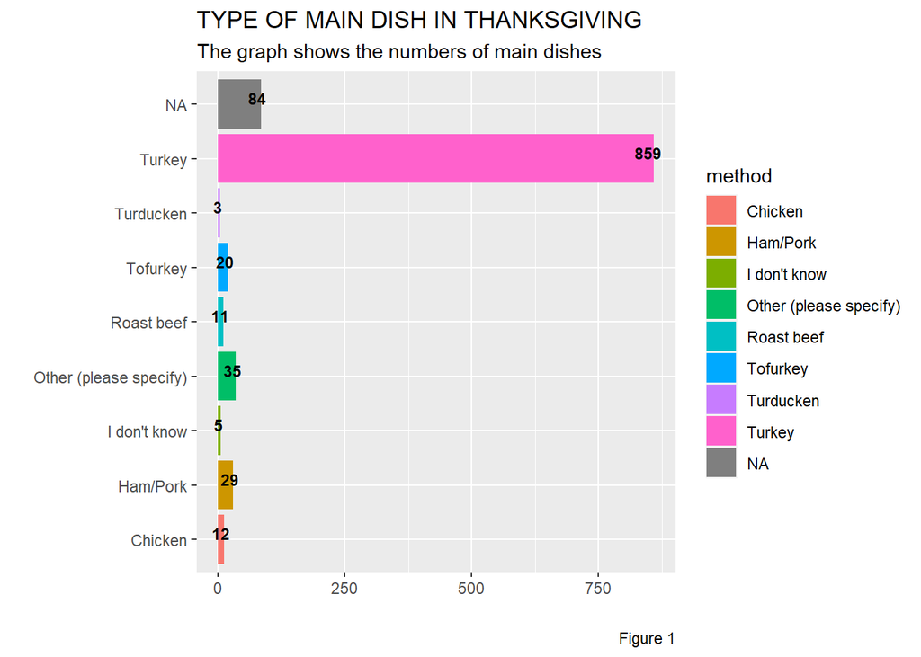

```r
thanksgiving_meals %>%
  group_by(main_dish) %>%
  count() %>%
  ungroup() %>%
  arrange(desc(main_dish)) %>%
  ggplot(aes(main_dish, n, fill = main_dish)) +
  geom_col() +
  geom_text(aes(label = n), fontface = "bold", size = 3, vjust = 0, hjust = 0.7) +
  coord_flip() +
  labs(x = "", y = "", fill = "method",
       title = "TYPE OF MAIN DISH IN THANKSGIVING",
       subtitle = "The graph shows the numbers of main dishes", caption = "Figure 1") +
  theme_grey()
```

Figure 1 shows the types of the main dish in Thanksgiving. Most families eat Turkey which is the traditional main dish in the Thanksgiving holiday.

*Data visualization:2*

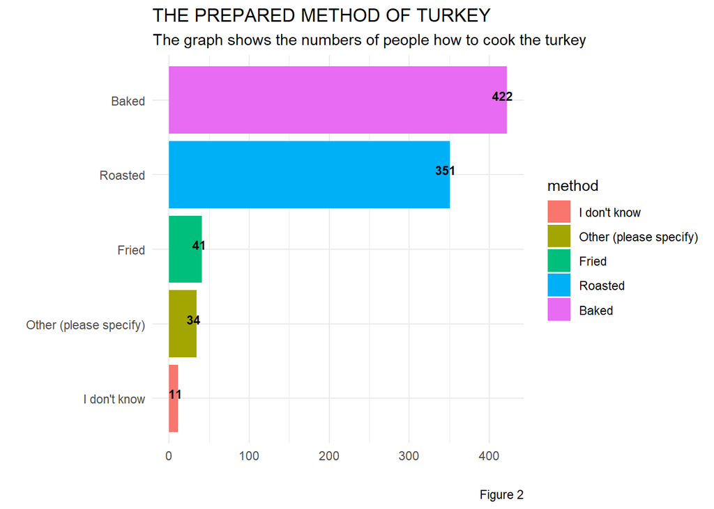

```r
data_viz <- thanksgiving_meals%>%
  select(main_dish, main_prep) %>%
  filter(main_dish == "Turkey") %>%
  count(main_prep) %>%
  arrange(desc(n))


data_viz %>%
  mutate(main_prep = fct_reorder(main_prep, n)) %>%
  ggplot(aes(main_prep, n, fill = main_prep)) +
  geom_col() +
  geom_text(aes(label = n), fontface = "bold", size = 3, vjust = 0, hjust = 0.7) +
  coord_flip() +
  labs(x = "", y = "", fill = "method",
       title = "THE PREPARED METHOD OF TURKEY",
       subtitle = "The graph shows the numbers of people how to cook the turkey", caption = "Figure 2") +
  theme_minimal()
```

Figure 2 was based on the result of Figure 1. The graph depicts the methods of how people cook their Turkey. Baking and Roasting were the main methods of cooking Turkey.

*Data visualisation:3*

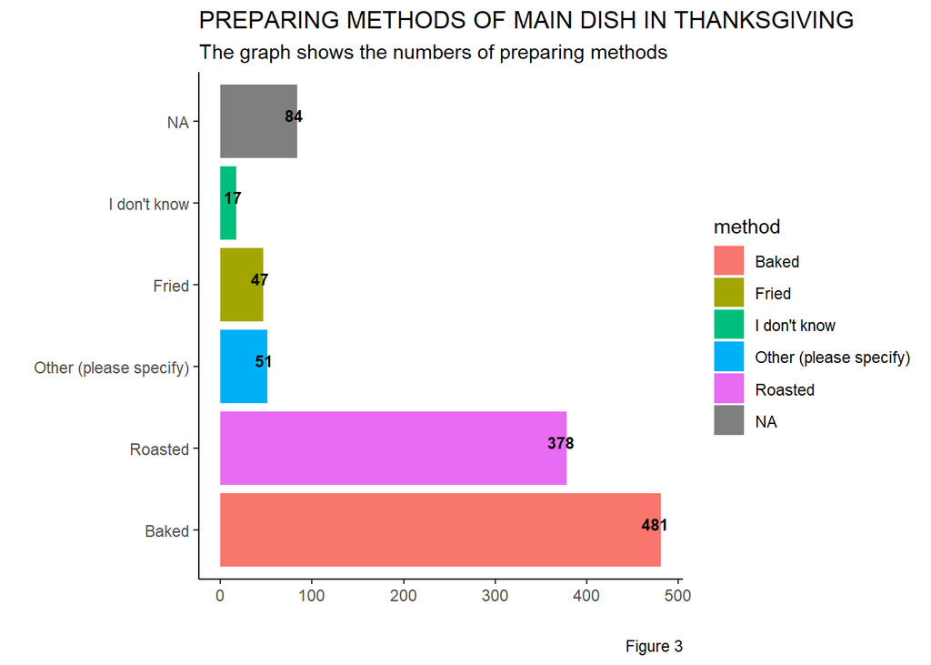

```r
thanksgiving_meals %>%
  group_by(main_prep) %>%
  count() %>%
  ungroup() %>%
  arrange(desc(main_prep)) %>%
  ggplot(aes(x = reorder(main_prep, - n), y = n, fill = main_prep)) +
  geom_col() +
  geom_text(aes(label = n), fontface = "bold", size = 3, vjust = 0, hjust = 0.7) +
  coord_flip() +
  labs(x = "", y = "", fill = "method",
       title = "PREPARING METHODS OF MAIN DISH IN THANKSGIVING",
       subtitle = "The graph shows the numbers of preparing methods", caption = "Figure 3") +
  theme_classic()
```

Figure 3 illustrates the methods of preparing dishes for Thanksgiving. According to the figure, the main cooking method is baking. Then the roasting is the second popular way to cook the main dish.

### **7.How many use cranberry sauce? How many use gravy?**

```r
thanksgiving_meals %>%
  group_by(cranberry) %>%
  count() %>%
  ungroup() %>%
  arrange(desc(n)) %>%
  kable()
```

| cranberry | n |
| --- | --- |
| Canned | 502 |
| Homemade | 301 |
| None | 146 |
| NA | 84 |
| Other (please specify) | 25 |

```r
thanksgiving_meals %>%
  group_by(gravy) %>%
  count( ) %>%
  ungroup() %>%
  filter(gravy == "Yes") %>%
  arrange(desc(n)) %>%
  kable()
```

| gravy | n |
| --- | --- |
| Yes | 892 |

As a result, 828 people use cranberry sauce and 892 people use gravy.

### **8-9.What is the distribution of those who celebrate across income ranges. Create a data viz. Write 2-3 sentences with your explanation of each insight.**

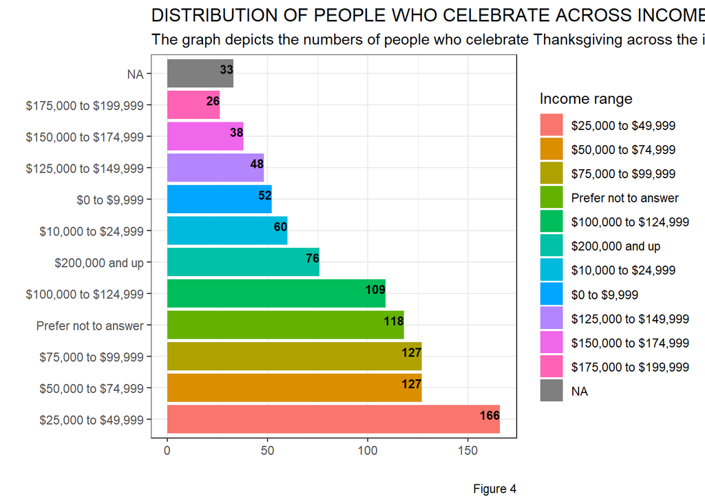

```r
income_range <- thanksgiving_meals %>%
  select(celebrate, family_income) %>%
  filter(celebrate == "Yes") %>%
  group_by(family_income) %>%
  count()%>%
  ungroup() %>%
  arrange(family_income)

income_range %>%
  mutate(family_income = fct_reorder(family_income, - n)) %>%
  ggplot(aes(x = family_income, y = n, fill = family_income)) +
  geom_col() +
  geom_text(aes(label = n), fontface = "bold", size = 3, vjust = 0, hjust = 1) +
  coord_flip() +
  labs(x = "", y = "", fill = "Income range",
       title = "DISTRIBUTION OF PEOPLE WHO CELEBRATE ACROSS INCOME RANGES",
       subtitle = "The graph depicts the numbers of people who celebrate Thanksgiving across the income range ", caption = "Figure 4") +
  theme_bw()
```

Firstly, a new data set named income range was created for filtering the people who celebrated Thanksgiving across the income range. Secondly, Figure 4 was built is to show the distribution of the people who celebrate across the income range. Column graph was chosen based on one discrete and one continuous variable. According to the graph, most of the people who celebrate Thanksgiving have an income ranging from $25,000 to $124,999.

### **10.Use the following code to create a new data set. Write 2-3 sentences with your explanation of what it does.**

```r
new_thankgiving_meals <- thanksgiving_meals %>%
  select(id, starts_with("side"),
       starts_with("pie"),
       starts_with("dessert")) %>%
  select(-side15, -pie13, -dessert12) %>%
  gather(type, value, -id) %>%
  filter(!is.na(value),
         !value %in% c("None", "Other (please specify)")) %>%
  mutate(type = str_remove(type, "\\d+"))
```

According to the given function, the new data set shows 3 variables which are id, type and value. The function selected all given variables from the main data set which means sorted and removed the “None” and NA (missing) variables. This function is purpose is clearing the data set.

### **11-12. Install package `widyr` and use `pairwise_cor()` function. Write 2-3 sentences with your explanation of what it does. Use this code for the new dataset. Write 1 sentence with your explanation of what insights it shows.**

```r
library(widyr)

new_thankgiving_meals %>%
  pairwise_cor(value, id, sort = TRUE) %>%
  kable()
```

| item1 | item2 | correlation |
| --- | --- | --- |
| Cookies | Brownies | 0.4109804 |
| Brownies | Cookies | 0.4109804 |
| Sweet Potato | Macaroni and cheese | 0.3646891 |
| Macaroni and cheese | Sweet Potato | 0.3646891 |
| Rolls/biscuits | Mashed potatoes | 0.3414698 |
| Mashed potatoes | Rolls/biscuits | 0.3414698 |
| Peach cobbler | Sweet Potato | 0.3387074 |
| Sweet Potato | Peach cobbler | 0.3387074 |
| Pumpkin | Mashed potatoes | 0.2900953 |
| Mashed potatoes | Pumpkin | 0.2900953 |
| Peach cobbler | Apple cobbler | 0.2877720 |
| Apple cobbler | Peach cobbler | 0.2877720 |
| Peach cobbler | Peach | 0.2797507 |
| Peach | Peach cobbler | 0.2797507 |
| Peach cobbler | Macaroni and cheese | 0.2784422 |
| Macaroni and cheese | Peach cobbler | 0.2784422 |
| Peach cobbler | Cornbread | 0.2650602 |
| Cornbread | Peach cobbler | 0.2650602 |
| Macaroni and cheese | Cornbread | 0.2580526 |
| Cornbread | Macaroni and cheese | 0.2580526 |
| Fudge | Brownies | 0.2412338 |
| Brownies | Fudge | 0.2412338 |
| Sweet Potato | Cornbread | 0.2316742 |
| Cornbread | Sweet Potato | 0.2316742 |
| Yams/sweet potato casserole | Green beans/green bean casserole | 0.2261861 |
| Green beans/green bean casserole | Yams/sweet potato casserole | 0.2261861 |
| Apple cobbler | Cornbread | 0.2217729 |
| Cornbread | Apple cobbler | 0.2217729 |
| Rolls/biscuits | Green beans/green bean casserole | 0.2204956 |
| Green beans/green bean casserole | Rolls/biscuits | 0.2204956 |

[output cut: 962 more lines]

### **13.Use `lm()` or randomForest() function to build a model that predict a family income based on data in the dataset. Compare 3 models using different set of input variables. Use different number of variables. Explain your choice of variables (3 sentences). Write 2 sentences explaining which model is best.**

```r
skim(thanksgiving_meals)
```

Data summary

| Name | thanksgiving_meals |
| --- | --- |
| Number of rows | 1058 |
| Number of columns | 65 |
| _______________________ |  |
| Column type frequency: |  |
| character | 64 |
| numeric | 1 |
| ________________________ |  |
| Group variables | None |

**Variable type: character**

| skim_variable | n_missing | complete_rate | min | max | empty | n_unique | whitespace |
| --- | --- | --- | --- | --- | --- | --- | --- |
| celebrate | 0 | 1.00 | 2 | 3 | 0 | 2 | 0 |
| main_dish | 84 | 0.92 | 6 | 22 | 0 | 8 | 0 |
| main_dish_other | 1023 | 0.03 | 4 | 85 | 0 | 32 | 0 |
| main_prep | 84 | 0.92 | 5 | 22 | 0 | 5 | 0 |
| main_prep_other | 1007 | 0.05 | 1 | 33 | 0 | 32 | 0 |
| stuffing | 84 | 0.92 | 4 | 22 | 0 | 4 | 0 |
| stuffing_other | 1022 | 0.03 | 4 | 46 | 0 | 29 | 0 |
| cranberry | 84 | 0.92 | 4 | 22 | 0 | 4 | 0 |
| cranberry_other | 1033 | 0.02 | 3 | 61 | 0 | 24 | 0 |
| gravy | 84 | 0.92 | 2 | 3 | 0 | 2 | 0 |
| side1 | 903 | 0.15 | 15 | 15 | 0 | 1 | 0 |
| side2 | 816 | 0.23 | 7 | 7 | 0 | 1 | 0 |
| side3 | 970 | 0.08 | 11 | 11 | 0 | 1 | 0 |
| side4 | 594 | 0.44 | 4 | 4 | 0 | 1 | 0 |
| side5 | 823 | 0.22 | 9 | 9 | 0 | 1 | 0 |
| side6 | 843 | 0.20 | 11 | 11 | 0 | 1 | 0 |
| side7 | 372 | 0.65 | 32 | 32 | 0 | 1 | 0 |
| side8 | 852 | 0.19 | 19 | 19 | 0 | 1 | 0 |
| side9 | 241 | 0.77 | 15 | 15 | 0 | 1 | 0 |
| side10 | 292 | 0.72 | 14 | 14 | 0 | 1 | 0 |
| side11 | 887 | 0.16 | 6 | 6 | 0 | 1 | 0 |
| side12 | 849 | 0.20 | 15 | 15 | 0 | 1 | 0 |
| side13 | 427 | 0.60 | 27 | 27 | 0 | 1 | 0 |
| side14 | 947 | 0.10 | 22 | 22 | 0 | 1 | 0 |
| side15 | 947 | 0.10 | 4 | 78 | 0 | 89 | 0 |
| pie1 | 544 | 0.49 | 5 | 5 | 0 | 1 | 0 |
| pie2 | 1023 | 0.03 | 10 | 10 | 0 | 1 | 0 |
| pie3 | 945 | 0.11 | 6 | 6 | 0 | 1 | 0 |
| pie4 | 925 | 0.13 | 9 | 9 | 0 | 1 | 0 |
| pie5 | 1022 | 0.03 | 13 | 13 | 0 | 1 | 0 |
| pie6 | 1019 | 0.04 | 8 | 8 | 0 | 1 | 0 |
| pie7 | 1024 | 0.03 | 5 | 5 | 0 | 1 | 0 |
| pie8 | 716 | 0.32 | 5 | 5 | 0 | 1 | 0 |
| pie9 | 329 | 0.69 | 7 | 7 | 0 | 1 | 0 |
| pie10 | 906 | 0.14 | 12 | 12 | 0 | 1 | 0 |
| pie11 | 1018 | 0.04 | 4 | 4 | 0 | 1 | 0 |
| pie12 | 987 | 0.07 | 22 | 22 | 0 | 1 | 0 |
| pie13 | 987 | 0.07 | 5 | 46 | 0 | 61 | 0 |
| dessert1 | 948 | 0.10 | 13 | 13 | 0 | 1 | 0 |
| dessert2 | 1042 | 0.02 | 8 | 8 | 0 | 1 | 0 |
| dessert3 | 930 | 0.12 | 8 | 8 | 0 | 1 | 0 |
| dessert4 | 986 | 0.07 | 11 | 11 | 0 | 1 | 0 |
| dessert5 | 867 | 0.18 | 10 | 10 | 0 | 1 | 0 |
| dessert6 | 854 | 0.19 | 7 | 7 | 0 | 1 | 0 |
| dessert7 | 1015 | 0.04 | 5 | 5 | 0 | 1 | 0 |
| dessert8 | 792 | 0.25 | 9 | 9 | 0 | 1 | 0 |
| dessert9 | 955 | 0.10 | 13 | 13 | 0 | 1 | 0 |
| dessert10 | 763 | 0.28 | 4 | 4 | 0 | 1 | 0 |
| dessert11 | 924 | 0.13 | 22 | 22 | 0 | 1 | 0 |
| dessert12 | 924 | 0.13 | 3 | 59 | 0 | 92 | 0 |
| prayer | 99 | 0.91 | 2 | 3 | 0 | 2 | 0 |
| travel | 107 | 0.90 | 59 | 80 | 0 | 4 | 0 |
| watch_program | 556 | 0.47 | 13 | 13 | 0 | 1 | 0 |
| kids_table_age | 107 | 0.90 | 2 | 13 | 0 | 12 | 0 |
| hometown_friends | 107 | 0.90 | 2 | 3 | 0 | 2 | 0 |
| friendsgiving | 107 | 0.90 | 2 | 3 | 0 | 2 | 0 |
| black_friday | 107 | 0.90 | 2 | 3 | 0 | 2 | 0 |
| work_retail | 107 | 0.90 | 2 | 3 | 0 | 2 | 0 |
| work_black_friday | 988 | 0.07 | 2 | 13 | 0 | 3 | 0 |
| community_type | 110 | 0.90 | 5 | 8 | 0 | 3 | 0 |
| age | 33 | 0.97 | 3 | 7 | 0 | 4 | 0 |
| gender | 33 | 0.97 | 4 | 6 | 0 | 2 | 0 |
| family_income | 33 | 0.97 | 12 | 20 | 0 | 11 | 0 |
| us_region | 59 | 0.94 | 7 | 18 | 0 | 9 | 0 |

**Variable type: numeric**

| skim_variable | n_missing | complete_rate | mean | sd | p0 | p25 | p50 | p75 | p100 | hist |
| --- | --- | --- | --- | --- | --- | --- | --- | --- | --- | --- |
| id | 0 | 1 | 4336731188 | 493783.4 | 4335894916 | 4336339486 | 4336796628 | 4337012140 | 4337954960 | ▅▃▇▂▂ |

```r
thanksgiving_meals$celebrate <- as_factor(thanksgiving_meals$celebrate)
thanksgiving_meals$age <- as_factor(thanksgiving_meals$age)
thanksgiving_meals$community_type <- as_factor(thanksgiving_meals$community_type)

#install.packages("randomForest")
library(randomForest)
rf1 <- randomForest(family_income ~ celebrate , data = factor, na.action = na.omit)

print(rf1)
```

```
##
## Call:
##  randomForest(formula = family_income ~ celebrate, data = factor,      na.action = na.omit)
##                Type of random forest: classification
##                      Number of trees: 500
## No. of variables tried at each split: 1
##
##         OOB estimate of  error rate: 82.05%
## Confusion matrix:
##                      $0 to $9,999 $10,000 to $24,999 $25,000 to $49,999
## $0 to $9,999                    0                  0                 52
## $10,000 to $24,999              0                  0                 60
## $25,000 to $49,999              0                  0                166
## $50,000 to $74,999              0                  0                127
## $75,000 to $99,999              0                  0                127
## $100,000 to $124,999            0                  0                109
## $125,000 to $149,999            0                  0                 48
## $150,000 to $174,999            0                  0                 38
## $175,000 to $199,999            0                  0                 26
## $200,000 and up                 0                  0                 76
## Prefer not to answer            0                  0                118
##                      $50,000 to $74,999 $75,000 to $99,999 $100,000 to $124,999
## $0 to $9,999                          0                  0                    0
## $10,000 to $24,999                    0                  0                    0
## $25,000 to $49,999                    0                  0                    0
## $50,000 to $74,999                    0                  0                    0
## $75,000 to $99,999                    0                  0                    0
## $100,000 to $124,999                  0                  0                    0
## $125,000 to $149,999                  0                  0                    0
## $150,000 to $174,999                  0                  0                    0
## $175,000 to $199,999                  0                  0                    0
## $200,000 and up                       0                  0                    0
## Prefer not to answer                  0                  0                    0
##                      $125,000 to $149,999 $150,000 to $174,999
## $0 to $9,999                            0                    0
## $10,000 to $24,999                      0                    0
## $25,000 to $49,999                      0                    0
## $50,000 to $74,999                      0                    0
## $75,000 to $99,999                      0                    0
## $100,000 to $124,999                    0                    0
```

[output cut: 14 more lines]

```
## $175,000 to $199,999                    0               0                    1
## $200,000 and up                         0               0                    4
## Prefer not to answer                    0               0                   18
##                      class.error
## $0 to $9,999          1.00000000
## $10,000 to $24,999    1.00000000
## $25,000 to $49,999    0.07777778
## $50,000 to $74,999    1.00000000
## $75,000 to $99,999    1.00000000
## $100,000 to $124,999  1.00000000
## $125,000 to $149,999  1.00000000
## $150,000 to $174,999  1.00000000
## $175,000 to $199,999  1.00000000
## $200,000 and up       1.00000000
## Prefer not to answer  0.86764706
```

```r
rf2 <- randomForest(family_income ~  age + community_type , data = factor, na.action = na.omit)

print(rf2)
```

```
##
## Call:
##  randomForest(formula = family_income ~ age + community_type,      data = factor, na.action = na.omit)
##                Type of random forest: classification
##                      Number of trees: 500
## No. of variables tried at each split: 1
##
##         OOB estimate of  error rate: 82.58%
## Confusion matrix:
##                      $0 to $9,999 $10,000 to $24,999 $25,000 to $49,999
## $0 to $9,999                   15                  0                 15
## $10,000 to $24,999              7                  0                 25
## $25,000 to $49,999              9                  0                 69
## $50,000 to $74,999              1                  0                 50
## $75,000 to $99,999              7                  0                 56
## $100,000 to $124,999            3                  0                 38
## $125,000 to $149,999            2                  0                 13
## $150,000 to $174,999            2                  0                  8
## $175,000 to $199,999            0                  0                  5
## $200,000 and up                 1                  0                 26
## Prefer not to answer            5                  0                 44
##                      $50,000 to $74,999 $75,000 to $99,999 $100,000 to $124,999
## $0 to $9,999                          0                  4                    3
## $10,000 to $24,999                    0                  4                   13
## $25,000 to $49,999                    0                 16                   46
## $50,000 to $74,999                    0                 19                   40
## $75,000 to $99,999                    1                 10                   43
## $100,000 to $124,999                  0                 11                   52
## $125,000 to $149,999                  0                  4                   29
## $150,000 to $174,999                  0                  5                   20
## $175,000 to $199,999                  0                  3                   17
## $200,000 and up                       0                  6                   39
## Prefer not to answer                  0                 16                   34
##                      $125,000 to $149,999 $150,000 to $174,999
## $0 to $9,999                            0                    0
## $10,000 to $24,999                      0                    0
## $25,000 to $49,999                      0                    0
## $50,000 to $74,999                      0                    0
## $75,000 to $99,999                      0                    0
## $100,000 to $124,999                    0                    0
```

[output cut: 14 more lines]

```
## $175,000 to $199,999                    0               0                    1
## $200,000 and up                         0               0                    4
## Prefer not to answer                    0               0                   19
##                      class.error
## $0 to $9,999           0.7115385
## $10,000 to $24,999     1.0000000
## $25,000 to $49,999     0.5843373
## $50,000 to $74,999     1.0000000
## $75,000 to $99,999     0.9212598
## $100,000 to $124,999   0.5229358
## $125,000 to $149,999   1.0000000
## $150,000 to $174,999   1.0000000
## $175,000 to $199,999   1.0000000
## $200,000 and up        1.0000000
## Prefer not to answer   0.8389831
```

```r
rf3 <- randomForest(family_income ~  celebrate + community_type + age , data = factor, na.action = na.omit)

print(rf3)
```

```
##
## Call:
##  randomForest(formula = family_income ~ celebrate + community_type +      age, data = factor, na.action = na.omit)
##                Type of random forest: classification
##                      Number of trees: 500
## No. of variables tried at each split: 1
##
##         OOB estimate of  error rate: 84.27%
## Confusion matrix:
##                      $0 to $9,999 $10,000 to $24,999 $25,000 to $49,999
## $0 to $9,999                    0                  0                 47
## $10,000 to $24,999              0                  0                 56
## $25,000 to $49,999              0                  0                148
## $50,000 to $74,999              0                  0                118
## $75,000 to $99,999              0                  0                121
## $100,000 to $124,999            0                  0                106
## $125,000 to $149,999            0                  0                 48
## $150,000 to $174,999            0                  0                 36
## $175,000 to $199,999            0                  0                 25
## $200,000 and up                 0                  0                 75
## Prefer not to answer            0                  0                117
##                      $50,000 to $74,999 $75,000 to $99,999 $100,000 to $124,999
## $0 to $9,999                          0                  0                    0
## $10,000 to $24,999                    0                  0                    0
## $25,000 to $49,999                    0                  0                    0
## $50,000 to $74,999                    0                  0                    1
## $75,000 to $99,999                    0                  0                    0
## $100,000 to $124,999                  0                  0                    0
## $125,000 to $149,999                  0                  0                    0
## $150,000 to $174,999                  0                  0                    0
## $175,000 to $199,999                  0                  0                    0
## $200,000 and up                       0                  0                    0
## Prefer not to answer                  0                  0                    0
##                      $125,000 to $149,999 $150,000 to $174,999
## $0 to $9,999                            0                    0
## $10,000 to $24,999                      0                    0
## $25,000 to $49,999                      0                    0
## $50,000 to $74,999                      0                    0
## $75,000 to $99,999                      0                    0
## $100,000 to $124,999                    0                    0
```

[output cut: 14 more lines]

```
## $175,000 to $199,999                    0               0                    1
## $200,000 and up                         0               0                    1
## Prefer not to answer                    0               0                    1
##                      class.error
## $0 to $9,999           1.0000000
## $10,000 to $24,999     1.0000000
## $25,000 to $49,999     0.1084337
## $50,000 to $74,999     1.0000000
## $75,000 to $99,999     1.0000000
## $100,000 to $124,999   1.0000000
## $125,000 to $149,999   1.0000000
## $150,000 to $174,999   1.0000000
## $175,000 to $199,999   1.0000000
## $200,000 and up        1.0000000
## Prefer not to answer   0.9915254
```

There 2 methods are used in Classical Machine Leaning methods which are Supervised and Unsupervised. Regression (lm) and Classification (randomForest) are models of the Supervised modelling approach. Choosing the model is based on the type of output. If the output will be a character, Classification is used in the modelling and is made a decision tree. In this report, RandomForest function is used because family income is the output variable that is characteristic.